# Part 1. Description

This homework bases on the models used in the first homework in the prediction of students' grades on the Alcohol Effects on Study dataset.

Firstly, the Random Forest Regressor model is trained on training data and explained with SHAP method from shap package for two randomly picked students (No. 103 and 371). These explanations are visualised below on the waterfall plot:

*Explanation for student's no. 103 prediction:*

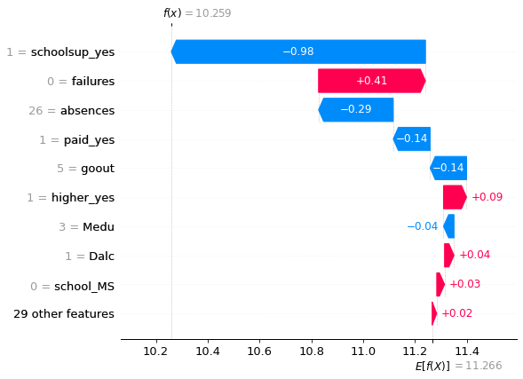

*Explanation for student no. 371 prediction:*

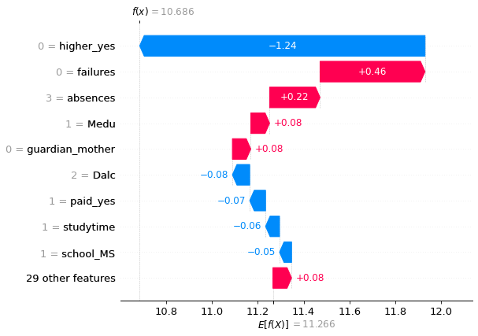

Here is the plot with explanations for this two students using Dalex package:

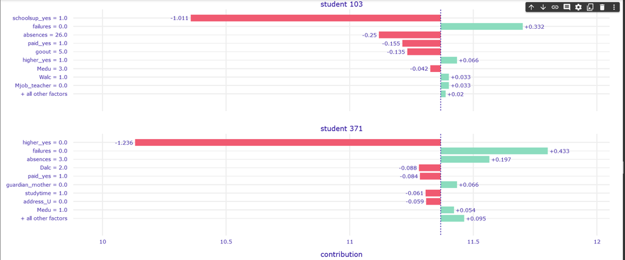

It is interesting that the explanations for both students differ slightly in shap and dalex. However, top features seem to remain the same.

Now I try to find two students with different variables of the highest importance and the same feature contributing differently (positively/negatively). It turns out that first two students meet this conditions:

*Explanation for student's no. 0 prediction:*

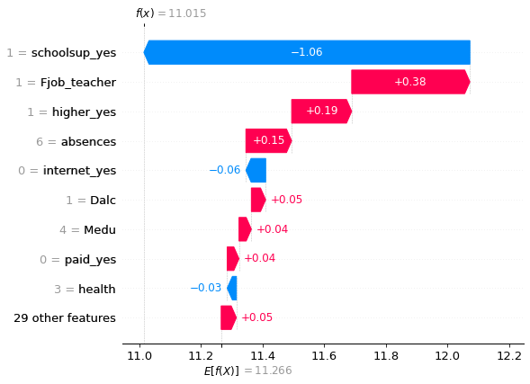

*Explanation for student's no. 1 prediction:*

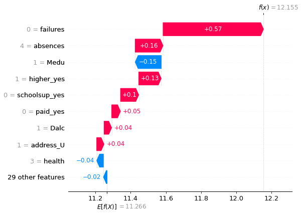

It is very convenient that this two students can be an example for the prediction, where the same feature is contributing positively to one prediction and negatively to the other. For the first student mother's education (Medu) is contributing slightly positively to the final score and for the second it is contributing negatively.

In the next task, I train and explain predictions made by Linear Regression model. On the example of 4th student I demonstarte the difference in explanations of this two models:

*Explanation for student's no. 4 prediction made by Random Forest Regression model:*

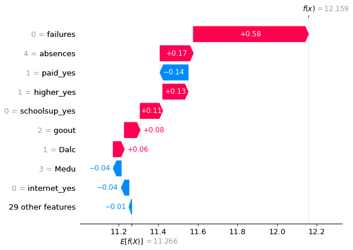

*Explanation for student's no. 4 prediction by Linear Regression model:*

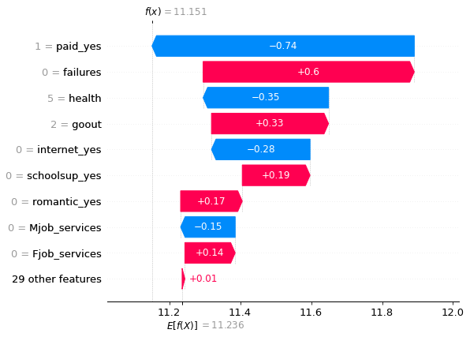

For the linear regression the most important feature is taking extra classes, while for the Random Forest it is the number of failures. In the linear regression other features matter, but for the random forest their contribution is much smaller than the first one's. It is intuitive difference for the model basing on decision trees (the first choice is much more important).

Shapley value of A with the given value function is 25.

# Part 2. Code

# Dependencies

```python
!pip install dalex
```

```
     |████████████████████████████████| 1.0 MB 5.1 MB/s
```

```python
!pip install shap
```

```
     |████████████████████████████████| 569 kB 5.0 MB/s
```

```python
import torch
import torch.nn as nn
import torch.nn.functional as F
import pandas as pd
import numpy as np

from sklearn.model_selection import train_test_split

import matplotlib.pyplot as plt

import shap
import dalex as dx

from sklearn.ensemble import RandomForestRegressor
from sklearn.linear_model import LinearRegression

import random
```

# Downloading Dataset

Firstly, in order to download Alcohol Effects on Study dataset, we mount google drive and upload kaggle API.

```python
from google.colab import drive
drive.mount('/content/gdrive')

from google.colab import files
```

```python
files.upload() #this will prompt you to upload the kaggle.jso
```

Upload widget is only available when the cell has been executed in the current browser session. Please rerun this cell to enable.

```
Saving kaggle.json to kaggle.json
```

```
{'kaggle.json': b'{"username":"paulinakaczyska","key":"a590f81fa200cd408d5cb174df96882a"}'}
```

```python
#make sure kaggle.json file is present
!ls -lha kaggle.json

#Install kaggle API client
!pip install -q kaggle

#kaggle API client expects the file to be in ~/.kaggle

#so move it there
!mkdir -p ~/.kaggle
!cp kaggle.json ~/.kaggle/

#seting permissions
!chmod 600 /root/.kaggle/kaggle.json

#check your directory before downloading the datasets
!pwd

#downloading
!kaggle datasets download -d whenamancodes/alcohol-effects-on-study

#unzipping
!unzip alcohol-effects-on-study.zip
```

```
-rw-r--r-- 1 root root 71 Oct 24 19:50 kaggle.json
/content
Downloading alcohol-effects-on-study.zip to /content
  0% 0.00/18.1k [00:00<?, ?B/s]
100% 18.1k/18.1k [00:00<00:00, 16.1MB/s]
Archive:  alcohol-effects-on-study.zip
  inflating: Maths.csv
  inflating: Portuguese.csv
```

# Data Preprocessing

```python
binary = ['school', 'sex', 'address', 'famsize', 'Pstatus','schoolsup', 'famsup', 'paid', 'activities', 'nursery','higher', 'internet', 'romantic']
categorical_nb = ['Mjob', 'Fjob', 'reason', 'guardian']
numerical = ['Medu', 'Fedu','traveltime', 'studytime','failures','famrel', 'freetime', 'goout', 'Dalc', 'Walc', 'health', 'absences']
```

The categorical data are one-hot encoded. Data is divided to input and output.

```python
math = pd.read_csv("Maths.csv", encoding = "UTF-8")
port = pd.read_csv("Portuguese.csv", encoding = "UTF-8")

math_i_c = pd.get_dummies(math[binary+categorical_nb],drop_first = True)
port_i_c = pd.get_dummies(port[binary+categorical_nb],drop_first = True)

math_o = math.iloc[:,-1]
port_o = port.iloc[:,-1]
```

```python
math
```

|  | school | sex | age | address | famsize | Pstatus | Medu | Fedu | Mjob | Fjob | ... | famrel | freetime | goout | Dalc | Walc | health | absences | G1 | G2 | G3 |
| --- | --- | --- | --- | --- | --- | --- | --- | --- | --- | --- | --- | --- | --- | --- | --- | --- | --- | --- | --- | --- | --- |
| 0 | GP | F | 18 | U | GT3 | A | 4 | 4 | at_home | teacher | ... | 4 | 3 | 4 | 1 | 1 | 3 | 6 | 5 | 6 | 6 |
| 1 | GP | F | 17 | U | GT3 | T | 1 | 1 | at_home | other | ... | 5 | 3 | 3 | 1 | 1 | 3 | 4 | 5 | 5 | 6 |
| 2 | GP | F | 15 | U | LE3 | T | 1 | 1 | at_home | other | ... | 4 | 3 | 2 | 2 | 3 | 3 | 10 | 7 | 8 | 10 |
| 3 | GP | F | 15 | U | GT3 | T | 4 | 2 | health | services | ... | 3 | 2 | 2 | 1 | 1 | 5 | 2 | 15 | 14 | 15 |
| 4 | GP | F | 16 | U | GT3 | T | 3 | 3 | other | other | ... | 4 | 3 | 2 | 1 | 2 | 5 | 4 | 6 | 10 | 10 |
| ... | ... | ... | ... | ... | ... | ... | ... | ... | ... | ... | ... | ... | ... | ... | ... | ... | ... | ... | ... | ... | ... |
| 390 | MS | M | 20 | U | LE3 | A | 2 | 2 | services | services | ... | 5 | 5 | 4 | 4 | 5 | 4 | 11 | 9 | 9 | 9 |
| 391 | MS | M | 17 | U | LE3 | T | 3 | 1 | services | services | ... | 2 | 4 | 5 | 3 | 4 | 2 | 3 | 14 | 16 | 16 |
| 392 | MS | M | 21 | R | GT3 | T | 1 | 1 | other | other | ... | 5 | 5 | 3 | 3 | 3 | 3 | 3 | 10 | 8 | 7 |
| 393 | MS | M | 18 | R | LE3 | T | 3 | 2 | services | other | ... | 4 | 4 | 1 | 3 | 4 | 5 | 0 | 11 | 12 | 10 |
| 394 | MS | M | 19 | U | LE3 | T | 1 | 1 | other | at_home | ... | 3 | 2 | 3 | 3 | 3 | 5 | 5 | 8 | 9 | 9 |

395 rows × 33 columns

Data is combined into input X and output Y arrays.

```python
math_array = pd.concat([math_i_c,math[numerical]],axis=1)
port_array = pd.concat([port_i_c,port[numerical]],axis=1)
X = pd.concat((math_array,port_array),axis = 0).reset_index().drop(['index'],axis=1)
Y = pd.concat((math_o,port_o),axis = 0).reset_index().drop(['index'],axis=1)
```

Division for test and train dataset is made using train_test_split from sklearn library.

```python
X_train, X_test, y_train, y_test = train_test_split(X,Y, test_size=100, train_size=len(X)-100)
```

# Training a tree-based ensemble model (Random Forest Regressor):

Firstly, I train Random Forest Regression using function from sklearn package. This method is a tree ensemble method.

```python
model_rfr = RandomForestRegressor(n_estimators = 300, max_depth=4, random_state=0)
model_rfr.fit(X_train, y_train)

y_pred = model_rfr.predict(X_train)
```

```
A column-vector y was passed when a 1d array was expected. Please change the shape of y to (n_samples,), for example using ravel().
```

I select two observations from the dataset and calculate the model's prediction.

```python
sample = random.sample(list(X.index),2)

X_sample = X.iloc[sample]
Y_sample = Y.iloc[sample]

Y_pred_sample = model_rfr.predict(X_sample)
```

```python
print('The grades of the two chosen students are:',Y_pred_sample, 'The students indexes are:', sample)
```

```
The grades of the two chosen students are: [10.2593648  10.68563446] The students indexes are: [103, 371]
```

I calculate the decomposition of predictions for the two students sampled above, using SHAP from dalex and shap.

```python
# explain the model with SHAP
explainer_rfr_shap = shap.explainers.Tree(model_rfr, data=X_train)
shap_values_rfr = explainer_rfr_shap(X_sample)
```

That is how shap_values for the two students look like:

```python
shap_values_rfr
```

[output not shown]

This are the waterfall plots for both students, explaining contribution of the features to the final prediction:

```
Explanation for student nr103grade prediction
```

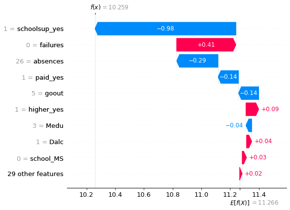

```
Explanation for student nr371grade prediction
```

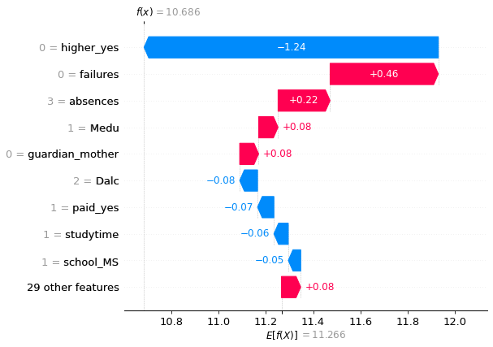

```python
for i in range(2):
  print('Explanation for student nr'+str(sample[i])+'grade prediction')
  shap.plots.waterfall(shap_values_rfr[i])
```

Now I do the same with Dalex.

```python
import dalex as dx
rfr_default = lambda m, d: m.predict(d)#[:, 1]

explainer = dx.Explainer(model_rfr, X_train, y_train, predict_function=rfr_default, label="GBM")
```

```
Preparation of a new explainer is initiated

  -> data              : 944 rows 38 cols
  -> target variable   : Parameter 'y' was a pandas.DataFrame. Converted to a numpy.ndarray.
  -> target variable   : 944 values
  -> model_class       : sklearn.ensemble._forest.RandomForestRegressor (default)
  -> label             : GBM
  -> predict function  : <function <lambda> at 0x7f60b13c2a70> will be used
  -> predict function  : Accepts pandas.DataFrame and numpy.ndarray.
  -> predicted values  : min = 1.77, mean = 11.4, max = 15.9
  -> model type        : regression will be used (default)
  -> residual function : difference between y and yhat (default)
  -> residuals         : min = -13.0, mean = -0.0173, max = 7.09
  -> model_info        : package sklearn

A new explainer has been created!
```

```
X does not have valid feature names, but RandomForestRegressor was fitted with feature names
```

Here are waterfall plots made with dalex:

```python
shap_attributions = [explainer.predict_parts(X.iloc[i], type="shap", label=f'student {i}') for i in sample]

shap_attributions[0].plot(shap_attributions[1::])
```

[interactive chart not shown]

It is interesting that the explanations for both students differ slightly in shap and dalex. However, top features seem to remain the same and the difference seems to be quantitative.

# Two observations with different variables of the highest importance and the same feature contributing differently

```python
shap_values_rfr_all = explainer_rfr_shap(X)
```

```python
shap_values_rfr_all.values.argmax(axis=1)
```

```
array([20, 30, 37, ..., 30, 30, 30])
```

Without looking further, the two first students in the dataframe seem to meet the condition. I check it on the visualisation:

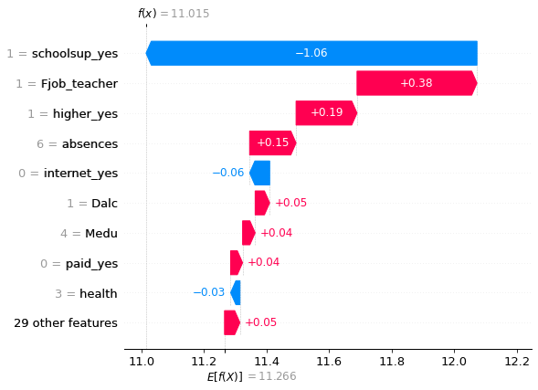

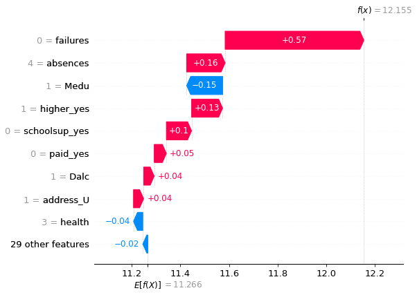

```python
for i in range(2):
  shap.plots.waterfall(shap_values_rfr_all[i])
```

It is very convenient that this two students can be an example for the prediction, where the same feature is contributing positively to one prediction and negatively to the other. For the first student mother's education (Medu) is contributing slightly positively to the final score and for the second it is contributing negatively.

# Training linear model

```python
model_lr = LinearRegression()
model_lr.fit(X_train, y_train)
```

```
LinearRegression()
```

```python
explainer_lr_shap = shap.explainers.Linear(model_lr,X)
shap_values_lr = explainer_lr_shap(X)
```

I check first students and for the 5th one the explanation differs quite much:

```
The SHAP decomposition of prediction for the 5th student in Random Forest Regression
```

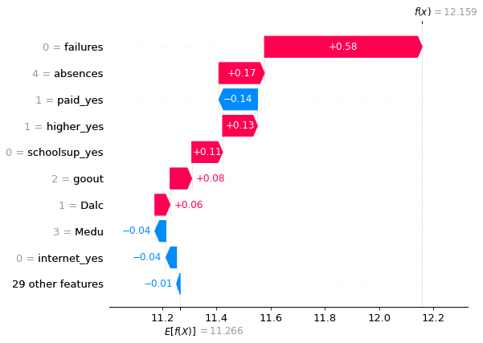

```
The SHAP decomposition of prediction for the 5th student in Linear Regression
```

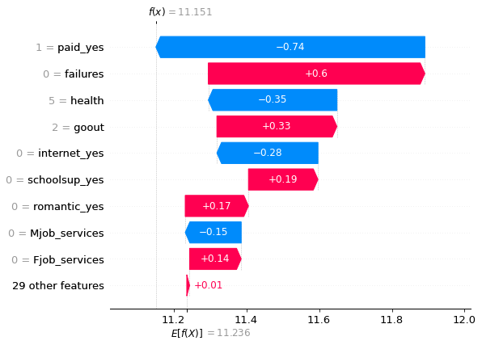

```python
print('The SHAP decomposition of prediction for the 5th student in Random Forest Regression')
shap.plots.waterfall(shap_values_rfr_all[4])
print('The SHAP decomposition of prediction for the 5th student in Linear Regression')
shap.plots.waterfall(shap_values_lr[4])
```

FOr the linear regression the most important feature is taking extra classes, while for the Random Forest it is the number of failures. In the linear regression other features matter, but for the random forest their contribution is much smaller than the first one's. It is intuitive difference for the model basing on decision trees (the first choice is much more important).

# The computation of Shapley Values

v() = 0\ v(A) = 20\ v(B) = 20\ v(C) = 60\ v(A,B) = 60\ v(A,C) = 70\ v(B,C) = 70\ v(A,B,C) = 100

$$\frac{1}{3!}\sum_{S\in\{B,C,\{B,C\},\{\}\}}S!(n-|S|-1)!(v(S\bigcup\{i\}-v(S)) = \frac{1}{6}(v(A,B)-v(B)+v(A,C)-v(C)+2*(v(A,B,C)-v(B,C))+2*(v(A)-v())) = \frac{1}{6}(40+10+60+40)=25$$

The Shapley value of A with this value function is 25